# Analiza czytelności wykresu w zależności od sposobu przedstawienia danych

Piotr Wilczyński, Michał Gromadzki

23/11/2021

# Wstęp

Przygotowaliśmy dwa eksperymenty, aby sprawdzić czy dobre praktyki opracowane lata temu mają zastosowanie w dzisiejszym świecie, w którym każdego dnia spotykamy się z wszelkiego rodzaju wizualizacjami danych. Rozesłaliśmy ankiety podzielone na trzy części. Każda z nich dotyczyła innej techniki przedstawiania informacji, która mogłaby utrudnić odczyt danych.

# Wykresy kołowe

Na początek zajmiemy się odczytywaniem danych z wykresów kołowych. W pierwszej ankiecie należało odpowiedzieć na poniższe pytanie:

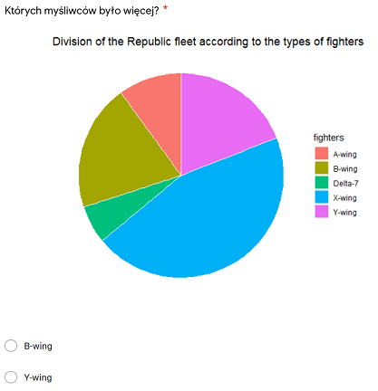

wykres 1

A w drugiej na:

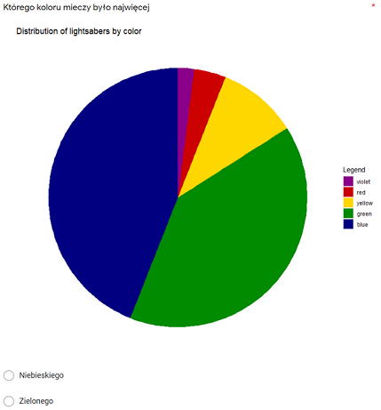

wykres 2

Trudność polegała na tym, że zarówno w pierwszym jak i drugim przypadku, ankietowani musieli stwierdzić, która spośród bliskich sobie wartości, była większa. Odpowiedzi byłe następujące:

|  | Dobre odpowiedzi | Złe odpowiedzi |
| --- | --- | --- |
| Wykres 1 | 4 | 12 |
| Wykres 2 | 14 | 2 |
| Suma | 18 | 14 |

Jak widzimy, ankietowani dobrze poradzili sobie z drugim wykresem, jednak w większości, źle odczytywali pierwszy. Sumując wyniki otrzymujemy, że zaledwie 18 na 32 (56%) odczyty danych z wykresów kołowych, były prawidłowe. Można zatem stwierdzić, że nie jest to najlepszy sposób prezentacji danych.

Dla porównania te same pytania, zaprezentowane na wykresach kolumnowych.

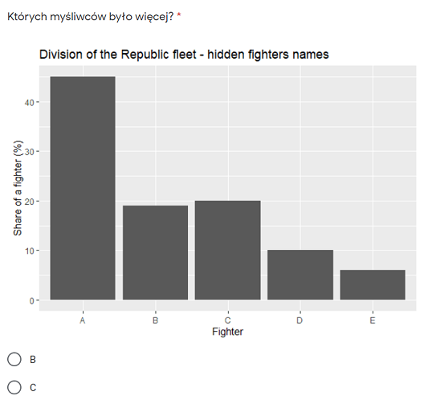

wykres 3

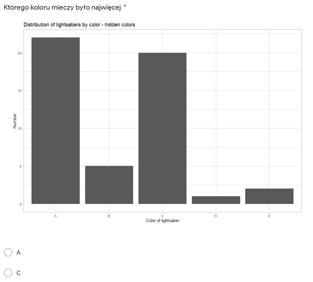

wykres 4

Odpowiedzi były następujące:

|  | Dobre odpowiedzi | Złe odpowiedzi |
| --- | --- | --- |
| Wykres 3 | 16 | 0 |
| Wykres 4 | 16 | 0 |
| Suma | 32 | 0 |

Jak widzimy, nikt nie miał problemu, aby odczytać te same dane z wykresu kolumnowego. Wydaje się, że jest to dokładniejszy sposób przedstawiania danych.

# Wykresy 3D

Kolejną techniką, która może zmniejszyć czytelność danych jest stosowanie kątów i grafiki 3D. Ankietowani mieli za zadanie oszacować wartości odczytane z wykresu.

Zadanie 1. Oszacuj wartości współrzędnej ‘z’ myśliwca: X-wing - Foxtrot  
Zadanie 2. Oszacuj wartości współrzędnej ‘z’ myśliwca: X-wing - Alpha  
Zadanie 3. Oszacuj wartości współrzędnej ‘z’ myśliwca: X-wing - Delta

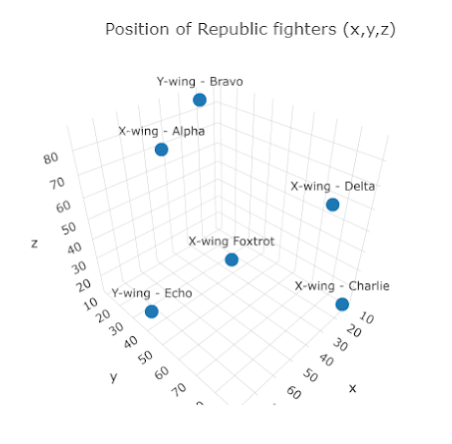

wykres 5

|  | Faktyczna wartość | Średnia arytmetyczna odpowiedzi | Minimalna podana wartość | Maksymalna podana wartość |
| --- | --- | --- | --- | --- |
| Zadanie 1 | 22 | 19 | 0 | 30 |
| Zadanie 2 | 69 | 72 | 67 | 80 |
| Zadanie 3 | 56 | 57 | 45 | 70 |

W drugiej ankiecie zadania wyglądały tak:  
Zadanie 1. Oszacuj ocenę drugiego filmu oryginalnej trylogii.  
Zadanie 2. Oszacuj ocenę trzeciego filmu z trylogii prequeli.  
Zadanie 3. Oszacuj ocenę pierwszego filmu z trylogii sequeli.

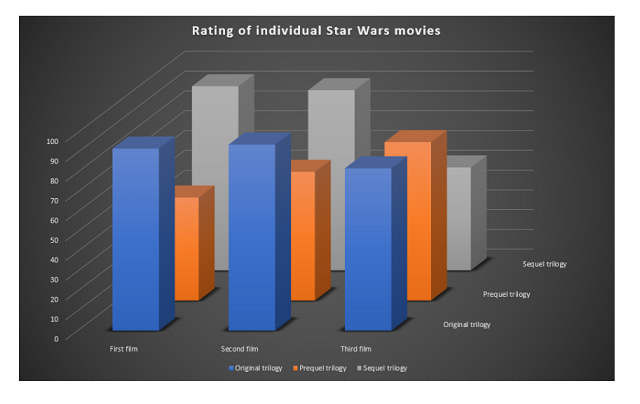

wykres 6

|  | Faktyczna wartość | Średnia arytmetyczna odpowiedzi | Minimalna podana wartość | Maksymalna podana wartość |
| --- | --- | --- | --- | --- |
| Zadanie 1 | 94 | 86 | 70 | 100 |
| Zadanie 2 | 80 | 72 | 48 | 90 |
| Zadanie 3 | 93 | 87 | 60 | 98 |

Jak widzimy, nie wszyscy dobrze sobie poradzili z pierwszym wykresem. Mimo tego, że średnia arytmetyczna jest całkiem blisko dokładnej wartości (+- 3pkt), to przedział odpowiedzi był duży - w skrajnym przypadku był długości 30. Drugi wykres był jeszcze gorzej odczytywany, ponieważ widać, że różnice między wartościami średnimi a faktycznymi są większe. Maksymalna wynosi 8. Subtelnie większe są również różnice pomiędzy wartościami minimalnymi i maksymalnymi.

# Źle dobrana skala

W tej części, zajęliśmy się problemami dotyczącymi skali. W pierwszej ankiecie należało odpowiedzieć na poniższe pytanie:

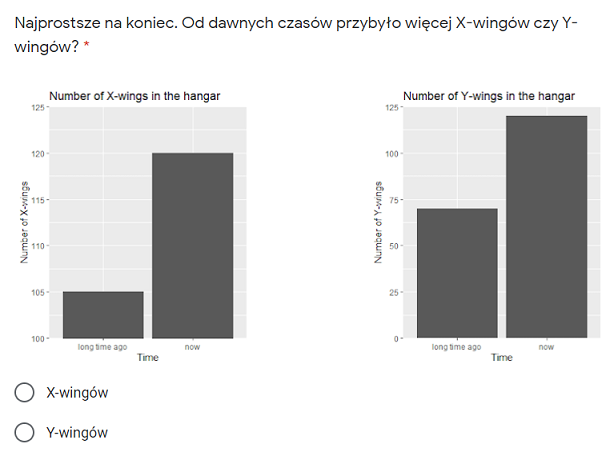

wykres 7

A w drugiej na:

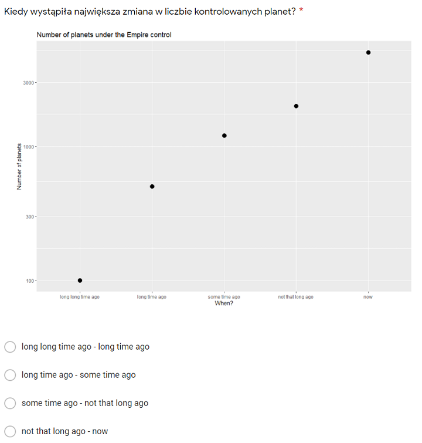

wykres 8

Trudność polegała na tym, że skala jest nieoczywista, w pierwszym przypadku nie zaczyna się od 0, a w drugim jest logarytmiczna.  
Odpowiedzi byłe następujące:

|  | Dobre odpowiedzi | Złe odpowiedzi |
| --- | --- | --- |
| Wykres 7 | 14 | 2 |
| Wykres 8 | 9 | 7 |
| Suma | 23 | 9 |

Jak widać osoby ankietowane zwracają uwagę na skalę niezaczynającą się od 0, natomiast nie są przyzwyczajone do skali logarytmicznej. Zaledwie 56% osób poprawnie odczytało wykres z drugiej ankiety.

# Podsumowanie

Analizując powyższe wyniki można dojść do wniosku, że nawet w społeczeństwie, w którym tak często jesteśmy wystawieni na przeróżne wizualizacje, mamy problemy z odczytywaniem niektórych form wykresów. Największe problemy sprawiają nam wykresy kołowe i 3D. Mamy trudności z odczytywaniem kątów i perspektywą.

Mimo to okazało się, że zwykle zauważamy, jeśli skala nie zaczyna się od zera i umiemy poprawnie zinterpretować taki wykres. Jednak, prawdopodobnie przez nieuwagę, nie zawsze odczytujemy dobrze skalę, gdy jest ona logarytmiczna.

Fakt, że od dzieciństwa jesteśmy przyzwyczajani do wizualizacji danych pozwolił nam poprawnie odczytywać wybrane nieoczywiste wykresy, ale wcale nie pomógł nam w poprawnej ewaluacji wartości z wykresów, wymagających wyobraźni przestrzennej.